# analysis

2022-05-01

## Introduction and background

During this project I tried to determine if casting Daniel Craig as James Bond was a good decision from the producers or not, what are the fan reactions, did they actually consider Craig negatively or rather neutral or positively. To boil this down, my research question was the following:

“Was Daniel Craig’s public reception by the fans overall positive or negative ?”

The data, scraping and cleaning code for the whole analysis can be found here: https://github.com/DaniDataScience/Data_Science_3

I did the following analysis in order to examine this question:

- scraping data from imdb
- cleaning and preparing data
- exploratory analysis analysis

## Conclusion

Based on the Exploratory analysis, and Analysis 1, 2, and 3, I concluded that Craig’s reviews are the negative reviews were more directed towards the movie (storytelling, plot, ect) and Craig s bond was only a secondary factor, with hime being a more controversial actoras Bond, rather than a negative one.

#### Scrapcing data from imdb

I scraped the reviews for all 5 James bond movies from imdb. The code for scraping can be found in the git repo.

The biggest difficulty here was that the imdb website does not post reviews above the 10th on a separate url that can be scraped directly, rather one has to load in more and more reviews from the same url page. I needed to do some research and figured out that if I pre-load the reviews in chrome and save the webpage as html, I can use that saved html for scraping.

I created a scraped dataset that contained an ID, the text of the review, the scoring (from 1 to 10) given by the reviewer, and the film (5 films in total). I scraped c.90% of all reviews per film, so had in total 8273 rows

#### Cleaning and preparing data

I had to do some minor data cleaning, and I also prepared the data for unstructured text analysis as much as possible:

- I created a new variable to indicate if the review mentions Daniel Craig
- I created a new variable where I extracted from the reviews that mention Craig only those sentences that talk about Daniel Craig directly or indirectly
- I created a new variable where I extracted from the reviews that mention Craig only those sentences that do NOT talk about Daniel Craig directly or indirectly
- I created a new variable that indicates if the review rating is more positive or more negative than the movie average

## Exploratory analysis

The following picture explains the structure of the total data and the part that I use.

So for each film there are a total of 300-500k ratings on imdb. Only c.1% of those who rated wrote a textual review as well. 65% of those who wrote a review mentioned Daniel Craig directly. Those reviews that mention Daniel Craig can be split into two groupes: sentences that directly mention or refer to Daniel Craig, and sentences that do not mention him.

My dataset contains the parts highlighted with blue. However, when looking at ratings in the preliminary analysis, I will look at the imdb ratings as well on an aggregate level, as this ill also give important insights.

[figure not shown]

#### Comparing total ratings and review ratings

In the graph below, I compared the avg. rating for the reviews I scraped and the total ratings from imdb. The movies are in timely order of airing, showing a declining trend for both categories.

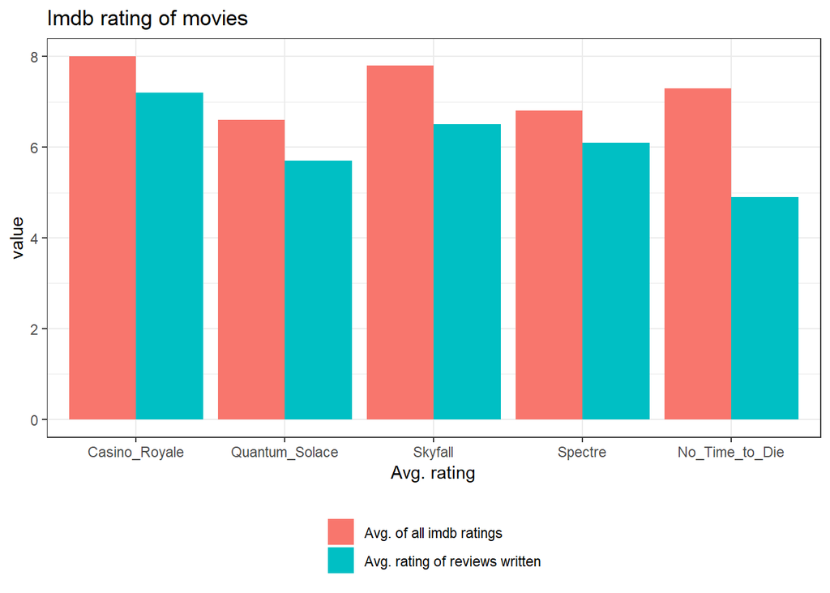

Key takeaways:

- Written review ratings are more negative on avg. than the average of all ratings found on imdb. The difference is significant, from 0.8 to as high as 2.3. The difference between the average of all imdb ratings and the average of reviews written is the biggest for No Time to Die, the latest movie.
- While the total imdb ratings slightly decline over time, the review ratings decline more rapidly

#### Extracting reviews that mention Craig

Lets split the written reviews I scraped into two groups: those that mention and those that do not mention Craig.

Craig is geenrally mentioned in more than 50% of the reviews.

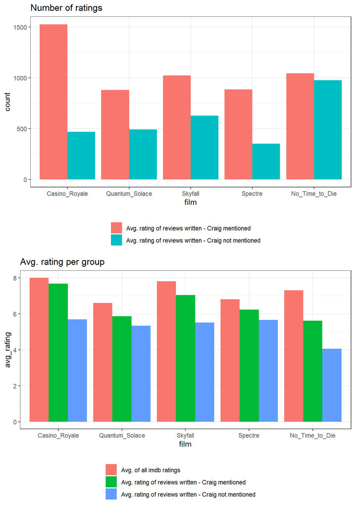

Summary of key takeaways:

- Daniel Craig is mentioned in the majority of reviews for all movies (except for No Time to Die where it is 50-50%), and reviews that mention him have a lower rating than the film, so we could say that he was the primary target of most negative comments. However, those who posted negative comments and did not mention Craig were even more negative about the film itself than about Daniel Craig
- Ratings on reviews that mention Craig are worse in all cases than the rating of the movie itself on imdb (“Avg. of all imdb ratings”), but ratings that do not mention craig are even worse.
- First Bond movie (Casino Royale) had good ratings, and Daniel Craig was mentioned in most reviews (as a new debut Bond actor) and received almost as good ratings as the movie did
- The last James Bond movie, Craig is only mentioned in c.50% of the reviews. The gap is the biggest here between the imdb total rating, the review ratings that mention Craig, and the reviews that do not mention Craig

Conclusions from the above facts:

- Daniel Craig was only partly the reason when a Bond movie was rated badly (below 7), the movie itself had many harsh critiques. Most of the reviews with ratings below the imdb rating do mention Craig, however, those that do not mention him are less numerous but have an even lower average rating

## Sentiment analysis

Not that we have an overall understanding, lets use sentiment analysis methods to further deepdive into the topic.

## Analysis 1: Adjective frequency analysis

I analyzed the frequency of key words (adjectives only). I did the exercise once for all reviews that do not contain Daniel Craig, and once for reviews that mention Craig. I removed stopwords, filtered the words to adjectives only using part_of_speech library, deleted some unneeded words to fine tune in the end, and determined the sentiment of the adjectives using bing library, and plotted occurrence counts on a graph.

Comparing the two graphs, we can see that those reviews that do not mention Craig have much more negative adjectives among the top25 frequent adjectives, 15 vs. 8. That is almost double the amount. The number of word counts is higher for reviews that mention Craig, but this is due to having much more reviews in this group.

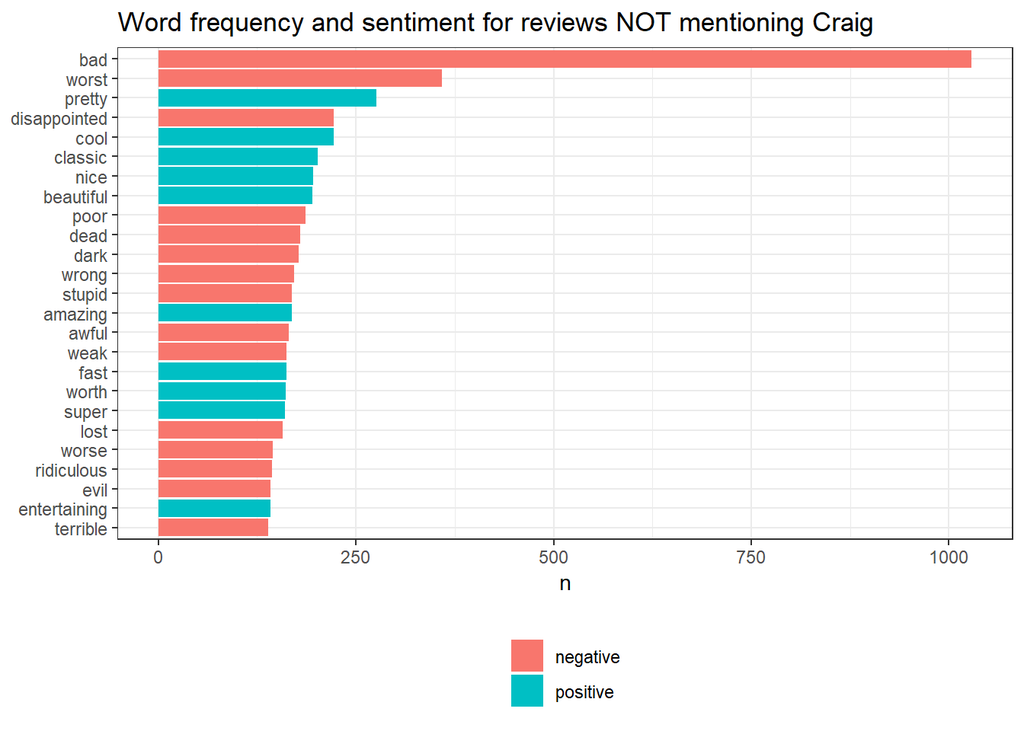

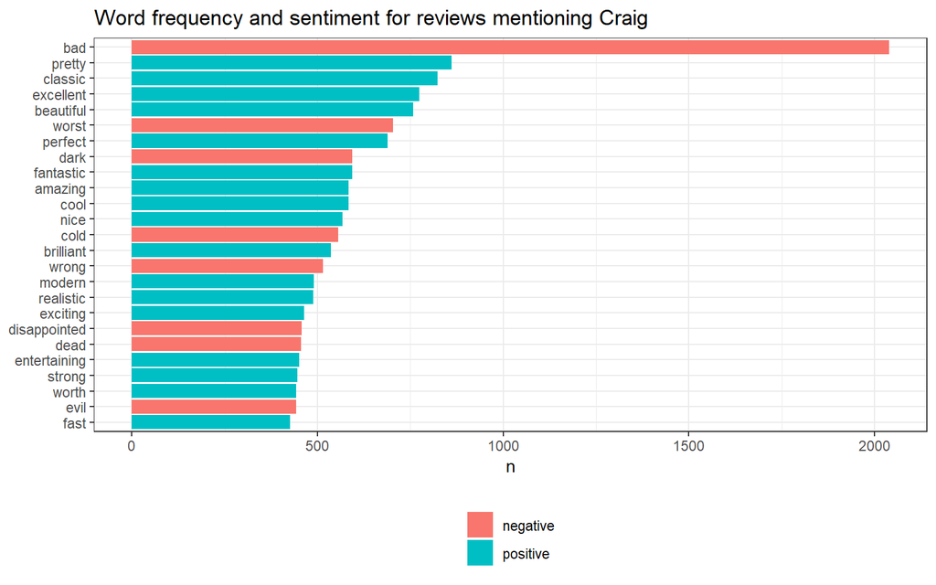

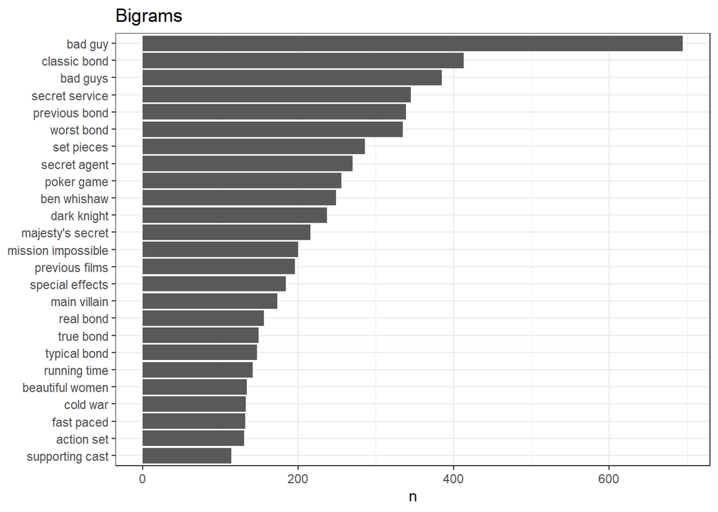

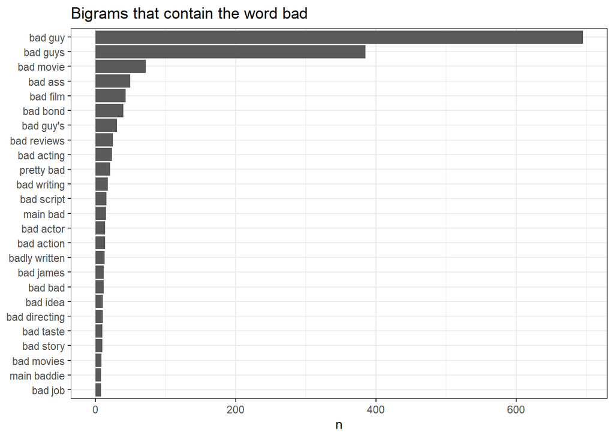

## Analysis 2: Adjective sentiment in sentences

In this section, I will focus on the written reviews only, and on sentiments. I filter the tidy dataset to adjectives again and use 2 lexicons, bing and nrc to evaluate.

I will use the following 3 grouped of reviews:

- Reviews that do not mention Daniel Craig at all (Craig_not_mentioned)
- Sentences that contain Daniel Craig from reviews that mention him (Craig_mentioned_Sentences_with_Craig)
- Sentences that do not contain Daniel Craig from reviews that mention him (Craig_mentioned_Sentences_without_Craig)

#### Bing lexicon

First I used the Bing lexicon to analyse the adjectives.

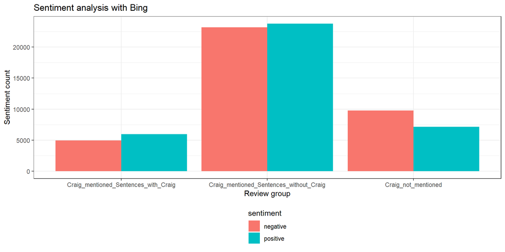

Using the narc lexicon

For the nrc lexicon results, I calculated relative frequency per the three groups, allowing a relative comparison per sentiment across the 3 groups. E.g. in reviews where Craig was not mentioned, anger has a c. 9.5% relative frequency, while for sentences that mention Craig thi is only c.7.5%. The nrc lexicon does not really change the overall picture we saw above: For negative sentiments such as “fear”, “anger”, “negative”, “sadness” have the highest relative frequency for reviews that do not mention Craig, while positive sentiments such as “joy”, “anticipation”,“positive” or”trust” is the highest for sentences where Craig is mentioned.

This reassures us of the conclusion we had for the Exploratory Analysis and for Analysis 1: the films themselves was the cause of most negative sentiments, Craig’s acting causing negative review is only secondary,.

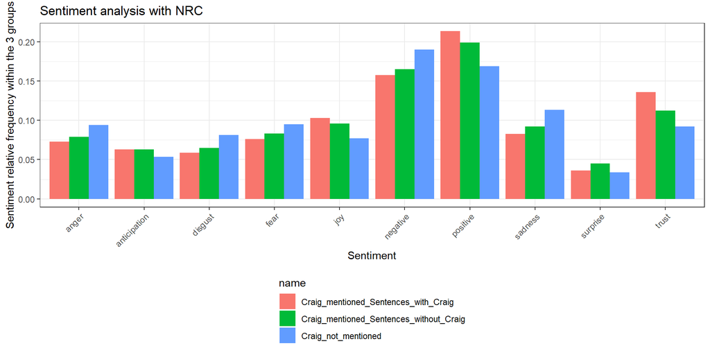

## Analysis 3: Sentiment analysis reviews that include Craig

For analysis 3 I checked the sentiment of hole reviews as one unit. I calculated the sentiment ratio of each review that mention Craig, using the nrc lexicon, and grouped the sentiments into 3 custom sentiment groups, negative, positive and neutral. I defined the “negative” sentiments as the anger, disgust, fear, negative and sadness sentiment groups within nrc, and anticipation, joy, positive as “positive”. I grouped into “other” the fear, surprise and trust categories.

The picture below is very balanced. For reviews where Craig is mentioned (True) the bulk of the data points are within the 0-25-0.5 range for both the negative and the positive sentiments, tilted slightly to the positive direction. For reviews that do not mention Craig (FALSE), the points are slightly tilted to the negative axis,

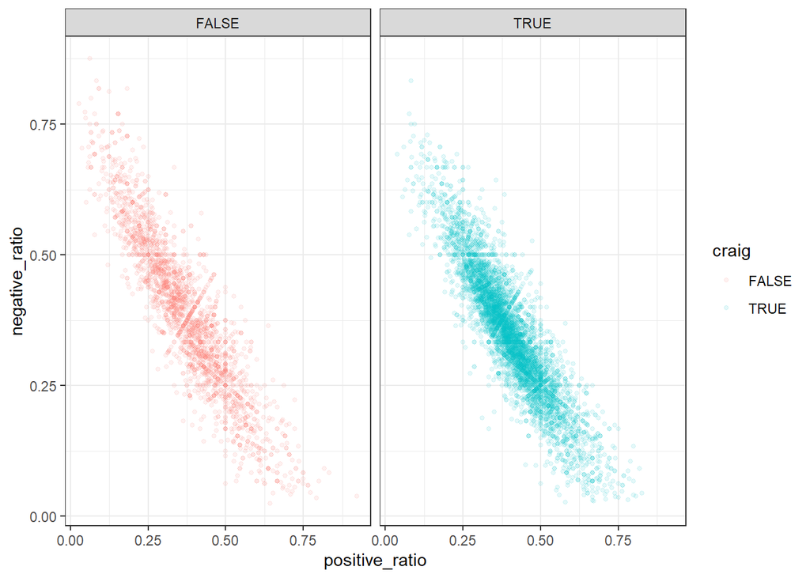

Summing up the above seen scatterplot, the reviews that mention Craig are slightly more positive than the reviews that do not mentiond him. This reassures the conclusion from Analysis 1 & 2.

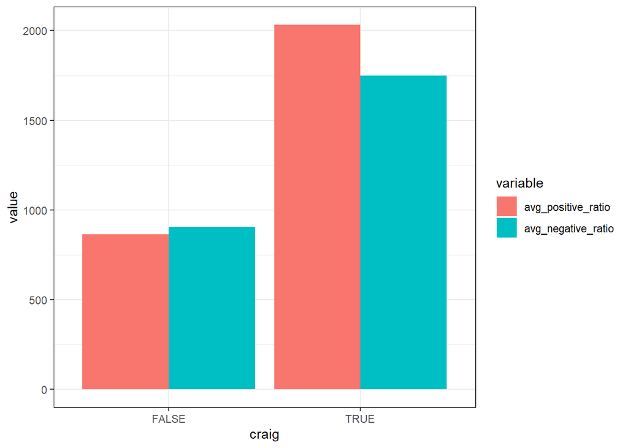

## APPENDIX: Analysis 4: Tf-idf analysis of reviews that include Craig vs reviews that do not

Finally I did a ft-idf analysis, however even after filtering names and other not needed words, I did not get a conclusive result. Thus I placed it in the appendix, as it is still interesting to see.

[figure not shown]